# EDA Notebook

```r
# loading tables:  assay_component_endpoint table from invitrodb
# & enrichment data (from Ryan Lougee[unreproducible])
library(data.table)
# queried from invitrodb 2020/12/18 14:00 PM
# read assay_component_endpoint table and its col names
aeid_table <- fread('InputData/aeid_table.txt')
aeid_table_col <- fread('InputData/aeid_table_col.txt')
# pasting the content instead of cleaning up aeid_table_col
col_names <- c('aeid', 'acid', 'assay_component_endpoint_name', 'export_ready', 'internal_ready', 'assay_component_endpoint_desc', 'assay_function_type', 'normalized_data_type', 'analysis_direction', 'burst_assay', 'key_positive_control', 'signal_direction', 'intended_target_type', 'intended_target_type_sub', 'intended_target_family', 'intended_target_family_sub', 'fit_all', 'cell_viability_assay', 'data_usability')
names(aeid_table) <-col_names
# enrichment data
baseline <- fread("InputData/ENRICHMENTS_invitrodb_v3_1_BASELINE_hitc_MC_2019.tsv")
burst <- fread("InputData/ENRICHMENTS_invitrodb_v3_1_BURST_hitc_MC_2019.tsv")
# extract aeid from 'Assay Name' column in aeid_table
aeid_table$aeid <- as.character(aeid_table$aeid)
library(stringr)
# make new column aeid using str_match
baseline$aeid <- str_match(baseline$`Assay Name`, ":\\s*(.*?)\\s*_")[,2]
burst$aeid <- str_match(burst$`Assay Name`, ":\\s*(.*?)\\s*_")[,2]
# match aenm from aeid_table by aeid
baseline_aenm <- merge( x = baseline,
                        y = aeid_table[, c("aeid", "assay_component_endpoint_name") ],
                        by = "aeid", all.x = T)
burst_aenm <- merge( x = burst,
                        y = aeid_table[, c("aeid", "assay_component_endpoint_name") ],
                        by = "aeid", all.x = T)
write.csv(burst_aenm, "OutputData/burst_aenm.csv")
write.csv(baseline_aenm, "OutputData/baseline_aenm.csv")
```

Visualizing the data. Using “label” of ToxPrint and “assay_component_endpoint_name” as the units of analysis for independent categorical variables. Dependent variables will be annotation attribute

Q1: What is the count distribution of label? Investigating prevelance in assay_component_endpoint_name [prmoiscuity] Q2: What is the count distribution of assay_component_endpoint_name? Investigating levels of diversity. [diversity]

Data preparation: collapse label by assay_component_endpoint_name collapse assay_component_endpoint_name by label

```r
baseline_table <- function(baseline){
baseline_label_table<- table(baseline$label)
baseline_txp_table<- table(baseline$descriptors_name)
baseline_aeid_table<- table(baseline$aeid)
# for txp label
baseline_label_table_df <- as.data.frame(baseline_label_table)
names(baseline_label_table_df) <- c('ToxPrint_label', 'enriched assay count')
# for txp number
baseline_txp_table_df <- as.data.frame(baseline_txp_table)
names(baseline_txp_table_df) <- c('ToxPrint', 'enriched assay count')
return(baseline_label_table_df)
}
```

plot

```r
#library(ggplot2)
#
ggplot(baseline[ordre()]) + geom_bar(aes(x = label))
#+
# scale_y_continuous("",label=baseline_label_table_df$ToxPrint) + coord_flip()
```

[output not shown]

Try wordcloud

```r
library(wordcloud)
dev.new(width = 10000, height = 10000, unit = "px")
set.seed(100)
wordcloud(baseline_label_table_df$ToxPrint_label, baseline_txp_table_df$`enriched assay count`, min.freq=100, max.words = 10, ,  colors=brewer.pal(6, "Dark2"), scale=c(4,.5), )
```

[output not shown]

trying wordcloud with ggplot2

```r
library(ggplot2)
library(ggwordcloud)
wordcloud_txp <- function(baseline_table,top, seed ){
baseline_label_table_df_top_10 <- baseline_label_table_df[order(-baseline_label_table_df$`enriched assay count`),][1:top,]
# plotting wordcloud for top 20 ToxPrint labels
set.seed(seed)
ggplot(baseline_label_table_df_top_10,
       aes(label = baseline_label_table_df_top_10$ToxPrint_label,
           size = baseline_label_table_df_top_10$`enriched assay count`,
           #color = factor(sample.int(10, nrow(baseline_label_table_df_top_10), replace = TRUE)) ) # color randomly assigned

         color = baseline_label_table_df_top_10$`enriched assay count`)) +
  geom_text_wordcloud() +
  #geom_text_wordcloud_area(shape = "diamond") +
  theme_minimal()
}
```

Making example images

```r
tiff(file="OutputImages/baseline_top20_45.tiff")
wordcloud_txp(baseline_table(baseline), 20, 45)
dev.off()
tiff(file="OutputImages/burst_top20_45.tiff")
wordcloud_txp(baseline_table(burst), 20, 45)
dev.off()
```

Rephrasing research questions: QQ1) Which ToxPrints are no longer enriched or newly enriched upon application of filter (burst)?

```r
## perform set operations on ToxPrints in either burst or baseline groups
baseline_txp <- unique(baseline$label)
burst_txp <- unique(burst$label)
# get union
baseline_burst_union <- union(burst_txp, baseline_txp)
# get intersection
baseline_burst_intersect <- intersect(burst_txp, baseline_txp)
# get diff between burst and baseline ( burst specific or gained)
burst_specific <- setdiff(burst_txp, baseline_txp)
# get diff between baseline and burst ( baseline specific or lost)
baseline_specific <- setdiff(baseline_txp, burst_txp)
# draw a set diagram
```

draw a venn diagram to visualize the counts

```r
# Load library
library(VennDiagram)
```

try again

```r
# area1
area2 <- length(c(burst_specific, baseline_burst_intersect))
# area2
area1 <- length(c(baseline_specific, baseline_burst_intersect))
#cross.area
cross.area <- length(baseline_burst_intersect)


# A more complicated diagram Demonstrating external area labels
venn.plot <- draw.pairwise.venn(
area1 = area1,
area2 = area2,
cross.area = cross.area,
category = c("First", "Second"),
fill = c("blue", "red"),
lty = "blank",
cex = 2,
cat.cex = 2,
cat.pos = c(285, 105),
cat.dist = 0.09,
cat.just = list(c(-1, -1), c(1, 1)),
ext.pos = 30,
ext.dist = -0.05,
ext.length = 0.85,
ext.line.lwd = 2,
ext.line.lty = "dashed"
)
grid.draw(venn.plot)
grid.newpage()
```

[output not shown]

try euler diagram

```r
  # Demonstrating an Euler diagram
venn.plot <- draw.pairwise.venn(
area1 = area1,
area2 = area2,
cross.area = cross.area,
category = c("First", "Second"),
cat.pos = c(0, 180),
euler.d = TRUE,
sep.dist = 0.03,
rotation.degree = 45
)
# Writing to file
tiff(filename = "OutputImages/burst_baseline_euler_diagram.tiff", compression = "lzw")
grid.draw(venn.plot)
```

```r
venn.plot <- draw.pairwise.venn(
area1 = area1,
area2 = area2,
cross.area = cross.area,
category = c("baseline", "burst"),
fill = c("blue", "red"),
lty = "blank",
cex = 2,
cat.cex = 2,
cat.pos = c(285, 105),
cat.dist = 0.09,
cat.just = list(c(-1, -1), c(1, 1)),
ext.pos = 30,
ext.dist = -0.05,
ext.length = 0.85,
ext.line.lwd = 2,
ext.line.lty = "dashed"
)
# Writing to file
tiff(filename = "OutputImages/burst_baseline_set_diagram.tiff", compression = "lzw")
grid.draw(venn.plot)
```

For overlapping ToxPrints, compute burst-baseline/baseline

plot horizontal bar

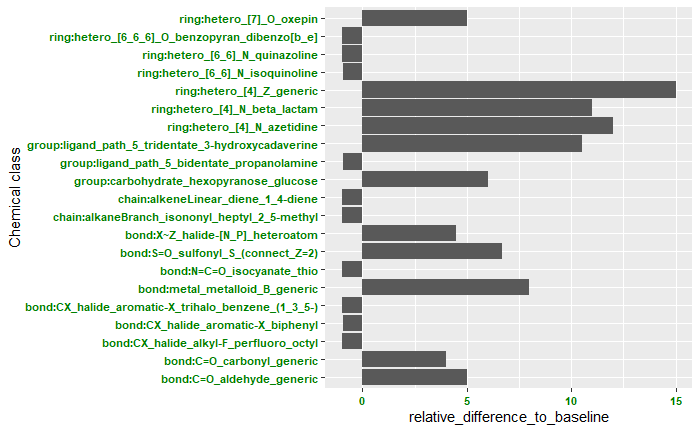